# Homework 7

Creating Fake Data Sets To Explore Hypotheses Go back to your “thinking on paper” exercise, and decide on a pattern that you might expect in your experiment if a specific hypothesis were true.

To start simply, assume that the data in each of your treatment groups follow a normal distribution. Specify the sample sizes, means, and variances for each group that would be reasonable if your hypothesis were true.

Using the methods we have covered in class, write a simple function to create a random data set that has these attributes. Organize these data into a data frame with the appropriate structure.

Now write a simple function to analyze the data (probably as an ANOVA or regression analysis, but possibly as a logistic regression or contingency table analysis. Write anothe function to generate a useful graph of the data.

Try running your analysis multiple times to get a feeling for how variable the results are with the same parameters, but different sets of random numbers.

Now begin adjusting the means of the different groups. Given the sample sizes you have chosen, how small can the differences between the groups be (the “effect size”) for you to still detect a significant pattern (p < 0.05).

Alternatively, for the effect sizes you originally hypothesized, what is the minimum sample size you would need in order to detect a statistically significant effect. Again, run the model a few times with the same parameter set to get a feeling for the effect of random variation in the data.

Write up your results in a markdown file. Be explicit in your explanation and justification for sample sizes, means, and variances.

If you have time, try repeating this exercise with one of the more sophisticated distributions, such as the gamma or negative binomial (depending on the kind of data you have). You will have to spend some time figuring out by trial and error the parameter values you will need to generate appropriate means and variances of the different groups.

Function to create data

```r
dataCreated<- function(mean1=100,mean2=80,n1=40,n2=40,sd1=43,sd2=38){
  mydf <- data.frame(control=rnorm(mean = mean1, n=n1, sd=sd1), test=rnorm(mean=mean2, n=n2, sd=sd2))
  return(mydf)
}
myDF <-dataCreated(mean1=100)
head(myDF)
```

```
##     control      test
## 1  51.34193  65.41781
## 2  55.38396  44.08005
## 3 168.60039  25.89882
## 4 127.82981  43.78353
## 5 107.50652 131.06953
## 6  66.22280  88.68256
```

Function for ANOVA

```r
library(reshape2)
myDF2 <- melt(myDF)
ANOVA <- function(data=myDF2){
  myANOVA <- aov(value~variable, data=data)
  summary(myANOVA)
}
ANOVA(data=myDF2)
```

```
##             Df Sum Sq Mean Sq F value  Pr(>F)
## variable     1  12168   12168   7.824 0.00649 **
## Residuals   78 121305    1555
## ---
## Signif. codes:  0 '***' 0.001 '**' 0.01 '*' 0.05 '.' 0.1 ' ' 1
```

```r
ANOVA()
```

```
##             Df Sum Sq Mean Sq F value  Pr(>F)
## variable     1  12168   12168   7.824 0.00649 **
## Residuals   78 121305    1555
## ---
## Signif. codes:  0 '***' 0.001 '**' 0.01 '*' 0.05 '.' 0.1 ' ' 1
```

```r
myANOVA <- aov(value~variable, data=myDF2)
summary(myANOVA)
```

```
##             Df Sum Sq Mean Sq F value  Pr(>F)
## variable     1  12168   12168   7.824 0.00649 **
## Residuals   78 121305    1555
## ---
## Signif. codes:  0 '***' 0.001 '**' 0.01 '*' 0.05 '.' 0.1 ' ' 1
```

Box Plot

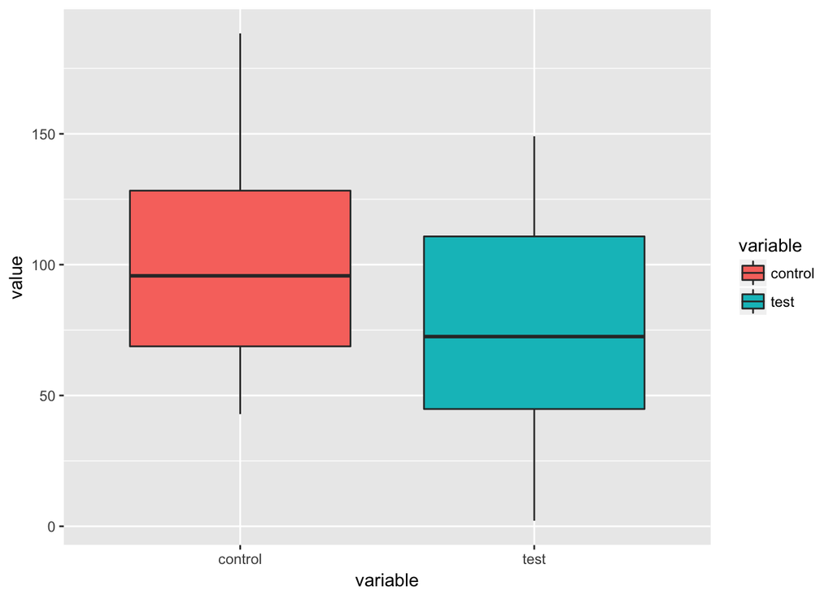

```r
library(ggplot2)
ANOVAPlot <- function(data=myDF2){
  ggplot(data=data,aes(x=variable, y=value, fill=variable)) + geom_boxplot()
}
ANOVAPlot()
```

ANOVA (Increase second mean)

```r
dataCreated<- function(mean1=100,mean2=200,n1=40,n2=40,sd1=43,sd2=38){
  mydf <- data.frame(control=rnorm(mean = mean1, n=n1, sd=sd1), test=rnorm(mean=mean2, n=n2, sd=sd2))
  return(mydf)
}
myDF <-dataCreated(mean1=100)
head(myDF)
```

```
##     control     test
## 1  91.81532 130.4484
## 2 127.60499 207.0550
## 3 106.60150 172.1524
## 4  71.30983 209.8335
## 5  70.69021 229.6339
## 6 104.10135 173.8753
```

```r
myDF2 <- melt(myDF)
ANOVA <- function(data=myDF2){
  myANOVA <- aov(value~variable, data=data)
  summary(myANOVA)
}
ANOVA(data=myDF2)
```

```
##             Df Sum Sq Mean Sq F value Pr(>F)
## variable     1 244393  244393     168 <2e-16 ***
## Residuals   78 113499    1455
## ---
## Signif. codes:  0 '***' 0.001 '**' 0.01 '*' 0.05 '.' 0.1 ' ' 1
```

```r
ANOVA()
```

```
##             Df Sum Sq Mean Sq F value Pr(>F)
## variable     1 244393  244393     168 <2e-16 ***
## Residuals   78 113499    1455
## ---
## Signif. codes:  0 '***' 0.001 '**' 0.01 '*' 0.05 '.' 0.1 ' ' 1
```

```r
myANOVA <- aov(value~variable, data=myDF2)
summary(myANOVA)
```

```
##             Df Sum Sq Mean Sq F value Pr(>F)
## variable     1 244393  244393     168 <2e-16 ***
## Residuals   78 113499    1455
## ---
## Signif. codes:  0 '***' 0.001 '**' 0.01 '*' 0.05 '.' 0.1 ' ' 1
```

ANOVA (Change sample size)

```r
dataCreated<- function(mean1=100,mean2=80,n1=25,n2=25,sd1=43,sd2=38){
  mydf <- data.frame(control=rnorm(mean = mean1, n=n1, sd=sd1), test=rnorm(mean=mean2, n=n2, sd=sd2))
  return(mydf)
}
myDF <-dataCreated(mean1=100)
head(myDF)
```

```
##     control      test
## 1 103.25492  24.50773
## 2  82.97391  47.21600
## 3 105.46808 110.30187
## 4 115.34293  81.85135
## 5 132.03705  43.82170
## 6  85.94938  83.72862
```

```r
myDF2 <- melt(myDF)
ANOVA <- function(data=myDF2){
  myANOVA <- aov(value~variable, data=data)
  summary(myANOVA)
}
ANOVA(data=myDF2)
```

```
##             Df Sum Sq Mean Sq F value Pr(>F)
## variable     1   5883    5883   4.583 0.0374 *
## Residuals   48  61615    1284
## ---
## Signif. codes:  0 '***' 0.001 '**' 0.01 '*' 0.05 '.' 0.1 ' ' 1
```

```r
ANOVA()
```

```
##             Df Sum Sq Mean Sq F value Pr(>F)
## variable     1   5883    5883   4.583 0.0374 *
## Residuals   48  61615    1284
## ---
## Signif. codes:  0 '***' 0.001 '**' 0.01 '*' 0.05 '.' 0.1 ' ' 1
```

```r
myANOVA <- aov(value~variable, data=myDF2)
summary(myANOVA)
```

```
##             Df Sum Sq Mean Sq F value Pr(>F)
## variable     1   5883    5883   4.583 0.0374 *
## Residuals   48  61615    1284
## ---
## Signif. codes:  0 '***' 0.001 '**' 0.01 '*' 0.05 '.' 0.1 ' ' 1
```